# Cyclistic Case Study

Reza Ahmad

10/25/2021

# Scenario

I am a junior data analyst working in the marketing analyst team at Cyclistic, a bike-share company in Chicago. The director of marketing believes the company’s future success depends on maximizing the number of annual memberships. Therefore, my team wants to understand how casual riders and annual members use Cyclistic bikes differently. From these insights, my team will design a new marketing strategy to convert casual riders into annual members. But first, Cyclistic executives must approve my recommendations, so they must be backed up with compelling data insights and professional data visualizations.

## Characters and teams

Cyclistic: A bike-share program that features more than 5,800 bicycles and 600 docking stations. Cyclistic sets itself apart by also offering reclining bikes, hand tricycles, and cargo bikes, making bike-share more inclusive to people with disabilities and riders who can’t use a standard two-wheeled bike. The majority of riders opt for traditional bikes; about 8% of riders use the assistive options. Cyclistic users are more likely to ride for leisure, but about 30% use them to commute to work each day.

Lily Moreno: The director of marketing and your manager. Moreno is responsible for the development of campaigns and initiatives to promote the bike-share program. These may include email, social media, and other channels.

Cyclistic marketing analytics team: A team of data analysts who are responsible for collecting, analyzing, and reporting data that helps guide Cyclistic marketing strategy. You joined this team six months ago and have been busy learning about Cyclistic’s mission and business goals — as well as how you, as a junior data analyst, can help Cyclistic achieve them.

Cyclistic executive team: The notoriously detail-oriented executive team will decide whether to approve the recommended marketing program.

## About the company

In 2016, Cyclistic launched a successful bike-share offering. Since then, the program has grown to a fleet of 5,824 bicycles that are geotracked and locked into a network of 692 stations across Chicago. The bikes can be unlocked from one station and returned to any other station in the system anytime.

Until now, Cyclistic’s marketing strategy relied on building general awareness and appealing to broad consumer segments. One approach that helped make these things possible was the flexibility of its pricing plans: single-ride passes, full-day passes, and annual memberships. Customers who purchase single-ride or full-day passes are referred to as casual riders. Customers who purchase annual memberships are Cyclistic members.

Cyclistic’s finance analysts have concluded that annual members are much more profitable than casual riders. Although the pricing flexibility helps Cyclistic attract more customers, Moreno believes that maximizing the number of annual members will be key to future growth. Rather than creating a marketing campaign that targets all-new customers, Moreno believes there is a very good chance to convert casual riders into members. She notes that casual riders are already aware of the Cyclistic program and have chosen Cyclistic for their mobility needs.

Moreno has set a clear goal: Design marketing strategies aimed at converting casual riders into annual members. In order to do that, however, the marketing analyst team needs to better understand how annual members and casual riders differ, why casual riders would buy a membership, and how digital media could affect their marketing tactics. Moreno and her team are interested in analyzing the Cyclistic historical bike trip data to identify trends.

# Data source

Cyclistic has provided historical trip data of the previous 12 months. The data is public, and we can locate the license to use the dataset [here](https://www.divvybikes.com/data-license-agreement). Human error and bias are minimal since the data is taken from the bikes themselves. The dataset does not provide personally identifiable information due to data-privacy concerns. It also means identifying pass purchases to determine if casual riders have purchased multiple single passes.

# Preparation

The data has 50000 to 800000 entries each month. To clean and process the large size of data, I use R Studio. All the data cleaning and the manipulating process are documented in this R Markdown.

# Data cleaning documentation

Reading raw CSV datasets into R Studio

Checking the structure of the datasets

```r
str(Oct2020)
```

```
## spec_tbl_df[,13] [388,653 × 13] (S3: spec_tbl_df/tbl_df/tbl/data.frame)
##  $ ride_id           : chr [1:388653] "ACB6B40CF5B9044C" "DF450C72FD109C01" "B6396B54A15AC0DF" "44A4AEE261B9E854" ...
##  $ rideable_type     : chr [1:388653] "electric_bike" "electric_bike" "electric_bike" "electric_bike" ...
##  $ started_at        : POSIXct[1:388653], format: "2020-10-31 19:39:43" "2020-10-31 23:50:08" ...
##  $ ended_at          : POSIXct[1:388653], format: "2020-10-31 19:57:12" "2020-11-01 00:04:16" ...
##  $ start_station_name: chr [1:388653] "Lakeview Ave & Fullerton Pkwy" "Southport Ave & Waveland Ave" "Stony Island Ave & 67th St" "Clark St & Grace St" ...
##  $ start_station_id  : num [1:388653] 313 227 102 165 190 359 313 125 NA 174 ...
##  $ end_station_name  : chr [1:388653] "Rush St & Hubbard St" "Kedzie Ave & Milwaukee Ave" "University Ave & 57th St" "Broadway & Sheridan Rd" ...
##  $ end_station_id    : num [1:388653] 125 260 423 256 185 53 125 313 199 635 ...
##  $ start_lat         : num [1:388653] 41.9 41.9 41.8 42 41.9 ...
##  $ start_lng         : num [1:388653] -87.6 -87.7 -87.6 -87.7 -87.7 ...
##  $ end_lat           : num [1:388653] 41.9 41.9 41.8 42 41.9 ...
##  $ end_lng           : num [1:388653] -87.6 -87.7 -87.6 -87.7 -87.7 ...
##  $ member_casual     : chr [1:388653] "casual" "casual" "casual" "casual" ...
##  - attr(*, "spec")=
##   .. cols(
##   ..   ride_id = col_character(),
##   ..   rideable_type = col_character(),
##   ..   started_at = col_datetime(format = ""),
##   ..   ended_at = col_datetime(format = ""),
##   ..   start_station_name = col_character(),
##   ..   start_station_id = col_double(),
##   ..   end_station_name = col_character(),
##   ..   end_station_id = col_double(),
##   ..   start_lat = col_double(),
##   ..   start_lng = col_double(),
##   ..   end_lat = col_double(),
##   ..   end_lng = col_double(),
##   ..   member_casual = col_character()
##   .. )
```

```r
str(Nov2020)
```

```
## spec_tbl_df[,13] [259,716 × 13] (S3: spec_tbl_df/tbl_df/tbl/data.frame)
##  $ ride_id           : chr [1:259716] "BD0A6FF6FFF9B921" "96A7A7A4BDE4F82D" "C61526D06582BDC5" "E533E89C32080B9E" ...
##  $ rideable_type     : chr [1:259716] "electric_bike" "electric_bike" "electric_bike" "electric_bike" ...
##  $ started_at        : POSIXct[1:259716], format: "2020-11-01 13:36:00" "2020-11-01 10:03:26" ...
##  $ ended_at          : POSIXct[1:259716], format: "2020-11-01 13:45:40" "2020-11-01 10:14:45" ...
##  $ start_station_name: chr [1:259716] "Dearborn St & Erie St" "Franklin St & Illinois St" "Lake Shore Dr & Monroe St" "Leavitt St & Chicago Ave" ...
##  $ start_station_id  : num [1:259716] 110 672 76 659 2 72 76 NA 58 394 ...
##  $ end_station_name  : chr [1:259716] "St. Clair St & Erie St" "Noble St & Milwaukee Ave" "Federal St & Polk St" "Stave St & Armitage Ave" ...
##  $ end_station_id    : num [1:259716] 211 29 41 185 2 76 72 NA 288 273 ...
##  $ start_lat         : num [1:259716] 41.9 41.9 41.9 41.9 41.9 ...
##  $ start_lng         : num [1:259716] -87.6 -87.6 -87.6 -87.7 -87.6 ...
##  $ end_lat           : num [1:259716] 41.9 41.9 41.9 41.9 41.9 ...
##  $ end_lng           : num [1:259716] -87.6 -87.7 -87.6 -87.7 -87.6 ...
##  $ member_casual     : chr [1:259716] "casual" "casual" "casual" "casual" ...
##  - attr(*, "spec")=
##   .. cols(
##   ..   ride_id = col_character(),
##   ..   rideable_type = col_character(),
##   ..   started_at = col_datetime(format = ""),
##   ..   ended_at = col_datetime(format = ""),
##   ..   start_station_name = col_character(),
##   ..   start_station_id = col_double(),
##   ..   end_station_name = col_character(),
##   ..   end_station_id = col_double(),
##   ..   start_lat = col_double(),
##   ..   start_lng = col_double(),
##   ..   end_lat = col_double(),
##   ..   end_lng = col_double(),
##   ..   member_casual = col_character()
##   .. )
```

```r
str(Dec2020)
```

```
## spec_tbl_df[,13] [131,573 × 13] (S3: spec_tbl_df/tbl_df/tbl/data.frame)
##  $ ride_id           : chr [1:131573] "70B6A9A437D4C30D" "158A465D4E74C54A" "5262016E0F1F2F9A" "BE119628E44F871E" ...
##  $ rideable_type     : chr [1:131573] "classic_bike" "electric_bike" "electric_bike" "electric_bike" ...
##  $ started_at        : POSIXct[1:131573], format: "2020-12-27 12:44:29" "2020-12-18 17:37:15" ...
##  $ ended_at          : POSIXct[1:131573], format: "2020-12-27 12:55:06" "2020-12-18 17:44:19" ...
##  $ start_station_name: chr [1:131573] "Aberdeen St & Jackson Blvd" NA NA NA ...
##  $ start_station_id  : chr [1:131573] "13157" NA NA NA ...
##  $ end_station_name  : chr [1:131573] "Desplaines St & Kinzie St" NA NA NA ...
##  $ end_station_id    : chr [1:131573] "TA1306000003" NA NA NA ...
##  $ start_lat         : num [1:131573] 41.9 41.9 41.9 41.9 41.8 ...
##  $ start_lng         : num [1:131573] -87.7 -87.7 -87.7 -87.7 -87.6 ...
##  $ end_lat           : num [1:131573] 41.9 41.9 41.9 41.9 41.8 ...
##  $ end_lng           : num [1:131573] -87.6 -87.7 -87.7 -87.7 -87.6 ...
##  $ member_casual     : chr [1:131573] "member" "member" "member" "member" ...
##  - attr(*, "spec")=
##   .. cols(
##   ..   ride_id = col_character(),
##   ..   rideable_type = col_character(),
##   ..   started_at = col_datetime(format = ""),
##   ..   ended_at = col_datetime(format = ""),
##   ..   start_station_name = col_character(),
##   ..   start_station_id = col_character(),
##   ..   end_station_name = col_character(),
##   ..   end_station_id = col_character(),
##   ..   start_lat = col_double(),
##   ..   start_lng = col_double(),
##   ..   end_lat = col_double(),
##   ..   end_lng = col_double(),
##   ..   member_casual = col_character()
##   .. )
```

```r
str(Jan2021)
```

```
## spec_tbl_df[,13] [96,834 × 13] (S3: spec_tbl_df/tbl_df/tbl/data.frame)
##  $ ride_id           : chr [1:96834] "E19E6F1B8D4C42ED" "DC88F20C2C55F27F" "EC45C94683FE3F27" "4FA453A75AE377DB" ...
##  $ rideable_type     : chr [1:96834] "electric_bike" "electric_bike" "electric_bike" "electric_bike" ...
##  $ started_at        : POSIXct[1:96834], format: "2021-01-23 16:14:19" "2021-01-27 18:43:08" ...
##  $ ended_at          : POSIXct[1:96834], format: "2021-01-23 16:24:44" "2021-01-27 18:47:12" ...
##  $ start_station_name: chr [1:96834] "California Ave & Cortez St" "California Ave & Cortez St" "California Ave & Cortez St" "California Ave & Cortez St" ...
##  $ start_station_id  : chr [1:96834] "17660" "17660" "17660" "17660" ...
##  $ end_station_name  : chr [1:96834] NA NA NA NA ...
##  $ end_station_id    : chr [1:96834] NA NA NA NA ...
##  $ start_lat         : num [1:96834] 41.9 41.9 41.9 41.9 41.9 ...
##  $ start_lng         : num [1:96834] -87.7 -87.7 -87.7 -87.7 -87.7 ...
##  $ end_lat           : num [1:96834] 41.9 41.9 41.9 41.9 41.9 ...
##  $ end_lng           : num [1:96834] -87.7 -87.7 -87.7 -87.7 -87.7 ...
##  $ member_casual     : chr [1:96834] "member" "member" "member" "member" ...
##  - attr(*, "spec")=
##   .. cols(
##   ..   ride_id = col_character(),
##   ..   rideable_type = col_character(),
##   ..   started_at = col_datetime(format = ""),
##   ..   ended_at = col_datetime(format = ""),
##   ..   start_station_name = col_character(),
##   ..   start_station_id = col_character(),
##   ..   end_station_name = col_character(),
##   ..   end_station_id = col_character(),
##   ..   start_lat = col_double(),
##   ..   start_lng = col_double(),
##   ..   end_lat = col_double(),
##   ..   end_lng = col_double(),
##   ..   member_casual = col_character()
##   .. )
```

```r
str(Feb2021)
```

```
## spec_tbl_df[,13] [49,622 × 13] (S3: spec_tbl_df/tbl_df/tbl/data.frame)
##  $ ride_id           : chr [1:49622] "89E7AA6C29227EFF" "0FEFDE2603568365" "E6159D746B2DBB91" "B32D3199F1C2E75B" ...
##  $ rideable_type     : chr [1:49622] "classic_bike" "classic_bike" "electric_bike" "classic_bike" ...
##  $ started_at        : POSIXct[1:49622], format: "2021-02-12 16:14:56" "2021-02-14 17:52:38" ...
##  $ ended_at          : POSIXct[1:49622], format: "2021-02-12 16:21:43" "2021-02-14 18:12:09" ...
##  $ start_station_name: chr [1:49622] "Glenwood Ave & Touhy Ave" "Glenwood Ave & Touhy Ave" "Clark St & Lake St" "Wood St & Chicago Ave" ...
##  $ start_station_id  : chr [1:49622] "525" "525" "KA1503000012" "637" ...
##  $ end_station_name  : chr [1:49622] "Sheridan Rd & Columbia Ave" "Bosworth Ave & Howard St" "State St & Randolph St" "Honore St & Division St" ...
##  $ end_station_id    : chr [1:49622] "660" "16806" "TA1305000029" "TA1305000034" ...
##  $ start_lat         : num [1:49622] 42 42 41.9 41.9 41.8 ...
##  $ start_lng         : num [1:49622] -87.7 -87.7 -87.6 -87.7 -87.6 ...
##  $ end_lat           : num [1:49622] 42 42 41.9 41.9 41.8 ...
##  $ end_lng           : num [1:49622] -87.7 -87.7 -87.6 -87.7 -87.6 ...
##  $ member_casual     : chr [1:49622] "member" "casual" "member" "member" ...
##  - attr(*, "spec")=
##   .. cols(
##   ..   ride_id = col_character(),
##   ..   rideable_type = col_character(),
##   ..   started_at = col_datetime(format = ""),
##   ..   ended_at = col_datetime(format = ""),
##   ..   start_station_name = col_character(),
##   ..   start_station_id = col_character(),
##   ..   end_station_name = col_character(),
##   ..   end_station_id = col_character(),
##   ..   start_lat = col_double(),
##   ..   start_lng = col_double(),
##   ..   end_lat = col_double(),
##   ..   end_lng = col_double(),
##   ..   member_casual = col_character()
##   .. )
```

```r
str(Mar2021)
```

```
## spec_tbl_df[,13] [228,496 × 13] (S3: spec_tbl_df/tbl_df/tbl/data.frame)
##  $ ride_id           : chr [1:228496] "CFA86D4455AA1030" "30D9DC61227D1AF3" "846D87A15682A284" "994D05AA75A168F2" ...
##  $ rideable_type     : chr [1:228496] "classic_bike" "classic_bike" "classic_bike" "classic_bike" ...
##  $ started_at        : POSIXct[1:228496], format: "2021-03-16 08:32:30" "2021-03-28 01:26:28" ...
##  $ ended_at          : POSIXct[1:228496], format: "2021-03-16 08:36:34" "2021-03-28 01:36:55" ...
##  $ start_station_name: chr [1:228496] "Humboldt Blvd & Armitage Ave" "Humboldt Blvd & Armitage Ave" "Shields Ave & 28th Pl" "Winthrop Ave & Lawrence Ave" ...
##  $ start_station_id  : chr [1:228496] "15651" "15651" "15443" "TA1308000021" ...
##  $ end_station_name  : chr [1:228496] "Stave St & Armitage Ave" "Central Park Ave & Bloomingdale Ave" "Halsted St & 35th St" "Broadway & Sheridan Rd" ...
##  $ end_station_id    : chr [1:228496] "13266" "18017" "TA1308000043" "13323" ...
##  $ start_lat         : num [1:228496] 41.9 41.9 41.8 42 42 ...
##  $ start_lng         : num [1:228496] -87.7 -87.7 -87.6 -87.7 -87.7 ...
##  $ end_lat           : num [1:228496] 41.9 41.9 41.8 42 42.1 ...
##  $ end_lng           : num [1:228496] -87.7 -87.7 -87.6 -87.6 -87.7 ...
##  $ member_casual     : chr [1:228496] "casual" "casual" "casual" "casual" ...
##  - attr(*, "spec")=
##   .. cols(
##   ..   ride_id = col_character(),
##   ..   rideable_type = col_character(),
##   ..   started_at = col_datetime(format = ""),
##   ..   ended_at = col_datetime(format = ""),
##   ..   start_station_name = col_character(),
##   ..   start_station_id = col_character(),
##   ..   end_station_name = col_character(),
##   ..   end_station_id = col_character(),
##   ..   start_lat = col_double(),
##   ..   start_lng = col_double(),
##   ..   end_lat = col_double(),
##   ..   end_lng = col_double(),
##   ..   member_casual = col_character()
##   .. )
```

```r
str(Apr2021)
```

```
## spec_tbl_df[,13] [337,230 × 13] (S3: spec_tbl_df/tbl_df/tbl/data.frame)
##  $ ride_id           : chr [1:337230] "6C992BD37A98A63F" "1E0145613A209000" "E498E15508A80BAD" "1887262AD101C604" ...
##  $ rideable_type     : chr [1:337230] "classic_bike" "docked_bike" "docked_bike" "classic_bike" ...
##  $ started_at        : POSIXct[1:337230], format: "2021-04-12 18:25:36" "2021-04-27 17:27:11" ...
##  $ ended_at          : POSIXct[1:337230], format: "2021-04-12 18:56:55" "2021-04-27 18:31:29" ...
##  $ start_station_name: chr [1:337230] "State St & Pearson St" "Dorchester Ave & 49th St" "Loomis Blvd & 84th St" "Honore St & Division St" ...
##  $ start_station_id  : chr [1:337230] "TA1307000061" "KA1503000069" "20121" "TA1305000034" ...
##  $ end_station_name  : chr [1:337230] "Southport Ave & Waveland Ave" "Dorchester Ave & 49th St" "Loomis Blvd & 84th St" "Southport Ave & Waveland Ave" ...
##  $ end_station_id    : chr [1:337230] "13235" "KA1503000069" "20121" "13235" ...
##  $ start_lat         : num [1:337230] 41.9 41.8 41.7 41.9 41.7 ...
##  $ start_lng         : num [1:337230] -87.6 -87.6 -87.7 -87.7 -87.7 ...
##  $ end_lat           : num [1:337230] 41.9 41.8 41.7 41.9 41.7 ...
##  $ end_lng           : num [1:337230] -87.7 -87.6 -87.7 -87.7 -87.7 ...
##  $ member_casual     : chr [1:337230] "member" "casual" "casual" "member" ...
##  - attr(*, "spec")=
##   .. cols(
##   ..   ride_id = col_character(),
##   ..   rideable_type = col_character(),
##   ..   started_at = col_datetime(format = ""),
##   ..   ended_at = col_datetime(format = ""),
##   ..   start_station_name = col_character(),
##   ..   start_station_id = col_character(),
##   ..   end_station_name = col_character(),
##   ..   end_station_id = col_character(),
##   ..   start_lat = col_double(),
##   ..   start_lng = col_double(),
##   ..   end_lat = col_double(),
##   ..   end_lng = col_double(),
##   ..   member_casual = col_character()
##   .. )
```

```r
str(May2021)
```

```
## spec_tbl_df[,13] [531,633 × 13] (S3: spec_tbl_df/tbl_df/tbl/data.frame)
##  $ ride_id           : chr [1:531633] "C809ED75D6160B2A" "DD59FDCE0ACACAF3" "0AB83CB88C43EFC2" "7881AC6D39110C60" ...
##  $ rideable_type     : chr [1:531633] "electric_bike" "electric_bike" "electric_bike" "electric_bike" ...
##  $ started_at        : POSIXct[1:531633], format: "2021-05-30 11:58:15" "2021-05-30 11:29:14" ...
##  $ ended_at          : POSIXct[1:531633], format: "2021-05-30 12:10:39" "2021-05-30 12:14:09" ...
##  $ start_station_name: chr [1:531633] NA NA NA NA ...
##  $ start_station_id  : chr [1:531633] NA NA NA NA ...
##  $ end_station_name  : chr [1:531633] NA NA NA NA ...
##  $ end_station_id    : chr [1:531633] NA NA NA NA ...
##  $ start_lat         : num [1:531633] 41.9 41.9 41.9 41.9 41.9 ...
##  $ start_lng         : num [1:531633] -87.6 -87.6 -87.7 -87.7 -87.7 ...
##  $ end_lat           : num [1:531633] 41.9 41.8 41.9 41.9 41.9 ...
##  $ end_lng           : num [1:531633] -87.6 -87.6 -87.7 -87.7 -87.7 ...
##  $ member_casual     : chr [1:531633] "casual" "casual" "casual" "casual" ...
##  - attr(*, "spec")=
##   .. cols(
##   ..   ride_id = col_character(),
##   ..   rideable_type = col_character(),
##   ..   started_at = col_datetime(format = ""),
##   ..   ended_at = col_datetime(format = ""),
##   ..   start_station_name = col_character(),
##   ..   start_station_id = col_character(),
##   ..   end_station_name = col_character(),
##   ..   end_station_id = col_character(),
##   ..   start_lat = col_double(),
##   ..   start_lng = col_double(),
##   ..   end_lat = col_double(),
##   ..   end_lng = col_double(),
##   ..   member_casual = col_character()
##   .. )
```

```r
str(Jun2021)
```

```
## spec_tbl_df[,13] [729,595 × 13] (S3: spec_tbl_df/tbl_df/tbl/data.frame)
##  $ ride_id           : chr [1:729595] "99FEC93BA843FB20" "06048DCFC8520CAF" "9598066F68045DF2" "B03C0FE48C412214" ...
##  $ rideable_type     : chr [1:729595] "electric_bike" "electric_bike" "electric_bike" "electric_bike" ...
##  $ started_at        : POSIXct[1:729595], format: "2021-06-13 14:31:28" "2021-06-04 11:18:02" ...
##  $ ended_at          : POSIXct[1:729595], format: "2021-06-13 14:34:11" "2021-06-04 11:24:19" ...
##  $ start_station_name: chr [1:729595] NA NA NA NA ...
##  $ start_station_id  : chr [1:729595] NA NA NA NA ...
##  $ end_station_name  : chr [1:729595] NA NA NA NA ...
##  $ end_station_id    : chr [1:729595] NA NA NA NA ...
##  $ start_lat         : num [1:729595] 41.8 41.8 41.8 41.8 41.8 ...
##  $ start_lng         : num [1:729595] -87.6 -87.6 -87.6 -87.6 -87.6 ...
##  $ end_lat           : num [1:729595] 41.8 41.8 41.8 41.8 41.8 ...
##  $ end_lng           : num [1:729595] -87.6 -87.6 -87.6 -87.6 -87.6 ...
##  $ member_casual     : chr [1:729595] "member" "member" "member" "member" ...
##  - attr(*, "spec")=
##   .. cols(
##   ..   ride_id = col_character(),
##   ..   rideable_type = col_character(),
##   ..   started_at = col_datetime(format = ""),
##   ..   ended_at = col_datetime(format = ""),
##   ..   start_station_name = col_character(),
##   ..   start_station_id = col_character(),
##   ..   end_station_name = col_character(),
##   ..   end_station_id = col_character(),
##   ..   start_lat = col_double(),
##   ..   start_lng = col_double(),
##   ..   end_lat = col_double(),
##   ..   end_lng = col_double(),
##   ..   member_casual = col_character()
##   .. )
```

```r
str(Jul2021)
```

```
## spec_tbl_df[,13] [822,410 × 13] (S3: spec_tbl_df/tbl_df/tbl/data.frame)
##  $ ride_id           : chr [1:822410] "0A1B623926EF4E16" "B2D5583A5A5E76EE" "6F264597DDBF427A" "379B58EAB20E8AA5" ...
##  $ rideable_type     : chr [1:822410] "docked_bike" "classic_bike" "classic_bike" "classic_bike" ...
##  $ started_at        : POSIXct[1:822410], format: "2021-07-02 14:44:36" "2021-07-07 16:57:42" ...
##  $ ended_at          : POSIXct[1:822410], format: "2021-07-02 15:19:58" "2021-07-07 17:16:09" ...
##  $ start_station_name: chr [1:822410] "Michigan Ave & Washington St" "California Ave & Cortez St" "Wabash Ave & 16th St" "California Ave & Cortez St" ...
##  $ start_station_id  : chr [1:822410] "13001" "17660" "SL-012" "17660" ...
##  $ end_station_name  : chr [1:822410] "Halsted St & North Branch St" "Wood St & Hubbard St" "Rush St & Hubbard St" "Carpenter St & Huron St" ...
##  $ end_station_id    : chr [1:822410] "KA1504000117" "13432" "KA1503000044" "13196" ...
##  $ start_lat         : num [1:822410] 41.9 41.9 41.9 41.9 41.9 ...
##  $ start_lng         : num [1:822410] -87.6 -87.7 -87.6 -87.7 -87.7 ...
##  $ end_lat           : num [1:822410] 41.9 41.9 41.9 41.9 41.9 ...
##  $ end_lng           : num [1:822410] -87.6 -87.7 -87.6 -87.7 -87.7 ...
##  $ member_casual     : chr [1:822410] "casual" "casual" "member" "member" ...
##  - attr(*, "spec")=
##   .. cols(
##   ..   ride_id = col_character(),
##   ..   rideable_type = col_character(),
##   ..   started_at = col_datetime(format = ""),
##   ..   ended_at = col_datetime(format = ""),
##   ..   start_station_name = col_character(),
##   ..   start_station_id = col_character(),
##   ..   end_station_name = col_character(),
##   ..   end_station_id = col_character(),
##   ..   start_lat = col_double(),
##   ..   start_lng = col_double(),
##   ..   end_lat = col_double(),
##   ..   end_lng = col_double(),
##   ..   member_casual = col_character()
##   .. )
```

```r
str(Aug2021)
```

```
## spec_tbl_df[,13] [804,352 × 13] (S3: spec_tbl_df/tbl_df/tbl/data.frame)
##  $ ride_id           : chr [1:804352] "99103BB87CC6C1BB" "EAFCCCFB0A3FC5A1" "9EF4F46C57AD234D" "5834D3208BFAF1DA" ...
##  $ rideable_type     : chr [1:804352] "electric_bike" "electric_bike" "electric_bike" "electric_bike" ...
##  $ started_at        : POSIXct[1:804352], format: "2021-08-10 17:15:49" "2021-08-10 17:23:14" ...
##  $ ended_at          : POSIXct[1:804352], format: "2021-08-10 17:22:44" "2021-08-10 17:39:24" ...
##  $ start_station_name: chr [1:804352] NA NA NA NA ...
##  $ start_station_id  : chr [1:804352] NA NA NA NA ...
##  $ end_station_name  : chr [1:804352] NA NA NA NA ...
##  $ end_station_id    : chr [1:804352] NA NA NA NA ...
##  $ start_lat         : num [1:804352] 41.8 41.8 42 42 41.8 ...
##  $ start_lng         : num [1:804352] -87.7 -87.7 -87.7 -87.7 -87.6 ...
##  $ end_lat           : num [1:804352] 41.8 41.8 42 42 41.8 ...
##  $ end_lng           : num [1:804352] -87.7 -87.6 -87.7 -87.7 -87.6 ...
##  $ member_casual     : chr [1:804352] "member" "member" "member" "member" ...
##  - attr(*, "spec")=
##   .. cols(
##   ..   ride_id = col_character(),
##   ..   rideable_type = col_character(),
##   ..   started_at = col_datetime(format = ""),
##   ..   ended_at = col_datetime(format = ""),
##   ..   start_station_name = col_character(),
##   ..   start_station_id = col_character(),
##   ..   end_station_name = col_character(),
##   ..   end_station_id = col_character(),
##   ..   start_lat = col_double(),
##   ..   start_lng = col_double(),
##   ..   end_lat = col_double(),
##   ..   end_lng = col_double(),
##   ..   member_casual = col_character()
##   .. )
```

```r
str(Sep2021)
```

```
## spec_tbl_df[,13] [756,147 × 13] (S3: spec_tbl_df/tbl_df/tbl/data.frame)
##  $ ride_id           : chr [1:756147] "9DC7B962304CBFD8" "F930E2C6872D6B32" "6EF72137900BB910" "78D1DE133B3DBF55" ...
##  $ rideable_type     : chr [1:756147] "electric_bike" "electric_bike" "electric_bike" "electric_bike" ...
##  $ started_at        : POSIXct[1:756147], format: "2021-09-28 16:07:10" "2021-09-28 14:24:51" ...
##  $ ended_at          : POSIXct[1:756147], format: "2021-09-28 16:09:54" "2021-09-28 14:40:05" ...
##  $ start_station_name: chr [1:756147] NA NA NA NA ...
##  $ start_station_id  : chr [1:756147] NA NA NA NA ...
##  $ end_station_name  : chr [1:756147] NA NA NA NA ...
##  $ end_station_id    : chr [1:756147] NA NA NA NA ...
##  $ start_lat         : num [1:756147] 41.9 41.9 41.8 41.8 41.9 ...
##  $ start_lng         : num [1:756147] -87.7 -87.6 -87.7 -87.7 -87.7 ...
##  $ end_lat           : num [1:756147] 41.9 42 41.8 41.8 41.9 ...
##  $ end_lng           : num [1:756147] -87.7 -87.7 -87.7 -87.7 -87.7 ...
##  $ member_casual     : chr [1:756147] "casual" "casual" "casual" "casual" ...
##  - attr(*, "spec")=
##   .. cols(
##   ..   ride_id = col_character(),
##   ..   rideable_type = col_character(),
##   ..   started_at = col_datetime(format = ""),
##   ..   ended_at = col_datetime(format = ""),
##   ..   start_station_name = col_character(),
##   ..   start_station_id = col_character(),
##   ..   end_station_name = col_character(),
##   ..   end_station_id = col_character(),
##   ..   start_lat = col_double(),
##   ..   start_lng = col_double(),
##   ..   end_lat = col_double(),
##   ..   end_lng = col_double(),
##   ..   member_casual = col_character()
##   .. )
```

Notice that Oct2020 and Nov2020 have two columns with different data types. To merge the datasets, all data types of the columns should be the same. Therefore, we need to transform the column with another data type.

Merging datasets

Summarizing day of the week, time of the day, and separating year, month, week, and day for future analysis.

```r
#Summarizing data for future analysis
all_rides$year <- format(all_rides$started_at, "%Y")
all_rides$month <- format(all_rides$started_at, "%m")
all_rides$week <- format(all_rides$started_at, "%W")
all_rides$day <- format(all_rides$started_at, "%d")
all_rides$weekday <- format(all_rides$started_at, "%A")
all_rides$YMD <- format(all_rides$started_at, "%Y-%m-%d")
all_rides$daytime <- format(all_rides$started_at, "%H:%M:%S")
```

The dataset is sorted by start time (started_at column) to see it in chronological order.

There were some missing values, such as incomplete station names. Therefore, the rows with missing values will be removed.

After examining the dataset, there were a few test rides within the rows.

```r
check_test <- all_rides_cleaned %>%
  filter(
    str_detect(start_station_name, fixed("test", ignore_case = TRUE))
    | str_detect(end_station_name, fixed("test", ignore_case = TRUE))
    | str_detect(start_station_id, fixed("test", ignore_case = TRUE))
    | str_detect(end_station_id, fixed("test", ignore_case = TRUE))
  ) %>%

  select(
    start_station_name,
    start_station_id,
    end_station_name,
    end_station_id
  ) %>%

  group_by(
    start_station_name
  ) %>%

  count(
    start_station_name
  )
```

Adding ride_length column that might be useful for future analysis.

Removing rows with ride_length less than 60 seconds that possibly a human error or false start. Also, rows with ride_length less than 0.

The ride_id should be unique. So, duplicated ride_id’s will be removed.

```r
checking_duplicates <- all_rides_cleaned %>%
  count(ride_id) %>%
  filter(n > 1)
```

Removing duplicates

# Summary

Most popular day of the year

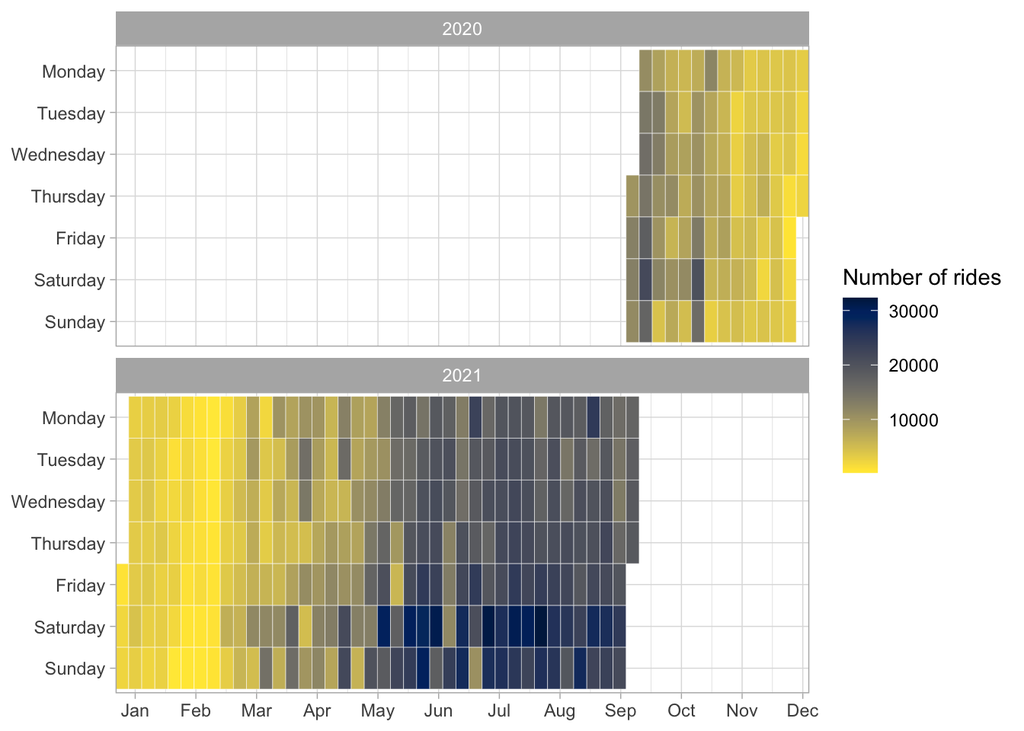

```r
#arranging weekday in order
all_rides_cleaned$weekday <- ordered(
  all_rides_cleaned$weekday,
  levels = c(
    "Monday", "Tuesday", "Wednesday", "Thursday",
    "Friday", "Saturday", "Sunday")
  )

#creating a dataframe to visualize the rides
heatmap_data <- all_rides_cleaned %>%

  select(
    YMD,
    weekday,
    week,
    year
  ) %>%

  group_by(
    YMD
  ) %>%

  mutate(
    numtrips = n()
  ) %>%

  distinct(
    YMD,
    .keep_all = TRUE
  )

#most popular day throughout the year
p1 <- ggplot(
  heatmap_data,
  aes(
    x = as.numeric(week),
    y = weekday,
    fill = numtrips
  )
) +

  # Use the viridis colour scheme to show the popularity of each day
  scale_fill_viridis(
    option = "E",
    direction = -1,
    name = "Number of rides"
  ) +

  # Create a rectangular heat map
  geom_tile(
    color = "white"
  ) +

  # Separate the heat maps by year
  facet_wrap(
    "year",
    ncol = 1
  )  +

  # Add x-axis labels to show the months of the year
  scale_x_continuous(
    expand = c(0, 0),
    breaks = seq(1, 52, length = 12),
    labels = c("Jan", "Feb", "Mar", "Apr", "May", "Jun",
               "Jul", "Aug", "Sep", "Oct", "Nov", "Dec")
    ) +

  # Reverse the y-axis so that the weekdays read vertically Monday to Sunday
  scale_y_discrete(limits = rev) +

  # Set the light theme
  theme_light() +

  # Remove any unnecessary labels
  theme(
    axis.title = element_blank()
  )

p1
```

From the heatmap, we can see that the most ride is between March and September, during the spring and summer season on the weekend. It indicates that most of the users use Cyclistic for leisure purposes.

The difference between annual members and casual riders can be seen in the section below.

Annual members and casual riders comparison on most popular day of the year.

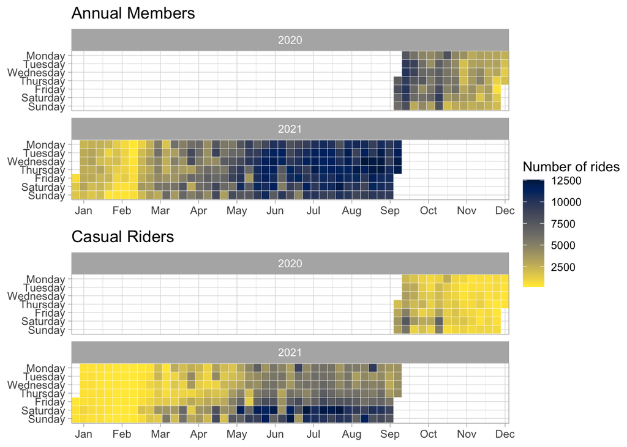

```r
#most popular day for casual riders and annual members
heatmap_data_member_casual <- all_rides_cleaned %>%

  select(
    YMD,
    weekday,
    week,
    year,
    member_casual,
  ) %>%

  group_by(
    member_casual,
    YMD
  ) %>%

  mutate(
    numtrips = n()
  ) %>%

  distinct(
    YMD,
    member_casual,
    .keep_all = TRUE
  )

#create a dataframe for annual members only
member_filter_heatmap <- heatmap_data_member_casual %>%
  filter(member_casual == "member")

#create a dataframe for casual riders only
casual_filter_heatmap <- heatmap_data_member_casual %>%
  filter(member_casual == "casual")

#create a heat map to show most popular time of year for members
p1_member <- ggplot(
  member_filter_heatmap,
  aes(
    x = as.numeric(week),
    y = weekday,
    fill = numtrips
  )
) +

  # Use the viridis colour scheme to show the popularity of each day
  scale_fill_viridis(
    option = "E",
    direction = -1,
    name = "Number of rides"
  ) +

  # Create a rectangular heat map
  geom_tile(
    colour = "white",
    na.rm = FALSE
  ) +

  # Separate the heat maps by year
  facet_wrap(
    "year",
    ncol = 1
  ) +

  # Reverse the y-axis so that the weekdays read vertically Monday to Sunday
  scale_y_discrete(
    limits = rev
  ) +

  # Add x-axis labels to show the months of the year
  scale_x_continuous(
    expand = c(0, 0),
    breaks = seq(1, 52, length = 12),
    labels = c("Jan", "Feb", "Mar", "Apr", "May", "Jun",
               "Jul", "Aug", "Sep", "Oct", "Nov", "Dec")
  ) +

  # Set the light theme
  theme_light() +

  # Remove any unnecessary labels
  theme(
    axis.title = element_blank()
  ) +

  # Add a title
  labs(title = "Annual Members")

#create a heat map to show most popular time of year for members
p1_casual <- ggplot(
  casual_filter_heatmap,
  aes(
    x = as.numeric(week),
    y = weekday,
    fill = numtrips
  )
) +

  # Use the viridis colour scheme to show the popularity of each day
  scale_fill_viridis(
    option = "E",
    direction = -1,
    name = "Number of rides"
  ) +

  # Create a rectangular heat map
  geom_tile(
    colour = "white",
    na.rm = FALSE
  ) +

  # Separate the heat maps by year
  facet_wrap(
    "year",
    ncol = 1
  ) +

  # Reverse the y-axis so that the weekdays read vertically Monday to Sunday
  scale_y_discrete(
    limits = rev
  ) +

  # Add x-axis labels to show the months of the year
  scale_x_continuous(
    expand = c(0, 0),
    breaks = seq(1, 52, length = 12),
    labels = c("Jan", "Feb", "Mar", "Apr", "May", "Jun",
               "Jul", "Aug", "Sep", "Oct", "Nov", "Dec")
  ) +

  # Set the light theme
  theme_light() +

  # Remove any unnecessary labels
  theme(
    axis.title = element_blank()
  ) +

  # Add a title
  labs(title = "Casual Riders")

# Combine the members only and casual riders only heat maps into one with one common legend
p1a <- ggarrange(
  p1_member,
  p1_casual,
  ncol = 1,
  nrow = 2,
  common.legend = TRUE,
  legend = "right"
)

p1a
```

There is a significant difference between annual members and casual riders in using Cyclistic bikes. Casual riders tend to use Cyclistic bikes on the weekend, while annual members are more consistent in using the service.

Most popular time of the day

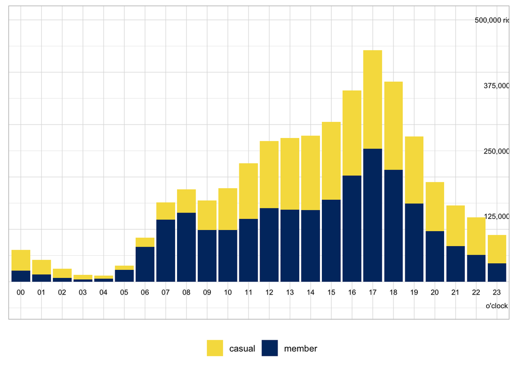

```r
#Convert the time of day variable to a date format
all_rides_cleaned$daytime_convert <- as.POSIXct(
  all_rides_cleaned$daytime, format = "%H:%M:%S")

#Group the time variable by hours
all_rides_cleaned$by60 <- cut(
  all_rides_cleaned$daytime_convert,
  breaks = "60 mins"
)

#Create data frame which counts the number of trips per hour for casual and member riders
bar_chart_data <- all_rides_cleaned %>%

  group_by(
    by60,
    member_casual
  ) %>%

  mutate(
    numtrips_0000s = (n()/1000)
  ) %>%

  distinct(
    by60,
    member_casual,
    numtrips_0000s
  )

#Create a circular bar chart to show the popularity of each hour
p2 <- ggplot(bar_chart_data) +

  #Create a stacked bar char
  geom_bar(
    aes(
      x = by60,
      y = numtrips_0000s,
      fill = member_casual
    ),
    stat="identity"
  ) +

  #Set light theme
  theme_light() +

  #Remove unnecessary labels
  theme(
    axis.title = element_blank(),
    axis.ticks = element_blank(),
    axis.text = element_blank(),
    legend.position = "bottom",
    legend.title = element_blank(),
  ) +

  #Add x-axis labels
  annotate(
    x = 1,
    y = -20,
    label = "00",
    geom = "text",
    size = 2.5
  ) +
  annotate(
    x = 2,
    y = -20,
    label = "01",
    geom = "text",
    size = 2.5
  ) +
  annotate(
    x = 3,
    y = -20,
    label = "02",
    geom = "text",
    size = 2.5
  ) +
  annotate(
    x = 4,
    y = -20,
    label = "03",
    geom = "text",
    size = 2.5
  ) +
  annotate(
    x = 5,
    y = -20,
    label = "04",
    geom = "text",
    size = 2.5
  ) +
  annotate(
    x= 6,
    y = -20,
    label = "05",
    geom = "text",
    size = 2.5
  ) +
  annotate(
    x = 7,
    y = -20,
    label = "06",
    geom = "text",
    size = 2.5
  ) +
  annotate(
    x = 8,
    y = -20,
    label = "07",
    geom = "text",
    size = 2.5
  ) +
  annotate(
    x = 9,
    y = -20,
    label = "08",
    geom = "text",
    size = 2.5
  ) +
  annotate(
    x = 10,
    y = -20,
    label = "09",
    geom = "text",
    size = 2.5
  ) +
  annotate(
    x = 11,
    y = -20,
    label = "10",
    geom = "text",
    size = 2.5
  ) +
  annotate(
    x = 12,
    y = -20,
    label = "11",
    geom = "text",
    size = 2.5
  ) +
  annotate(
    x = 13,
    y = -20,
    label = "12",
    geom = "text",
    size = 2.5
  ) +
  annotate(
    x = 14,
    y = -20,
    label = "13",
    geom = "text",
    size = 2.5
  ) +
  annotate(
    x = 15,
    y = -20,
    label = "14",
    geom = "text",
    size = 2.5
  ) +
  annotate(
    x = 16,
    y = -20,
    label = "15",
    geom = "text",
    size = 2.5
  ) +
  annotate(
    x = 17,
    y = -20,
    label = "16",
    geom = "text",
    size = 2.5
  ) +
  annotate(
    x = 18,
    y = -20,
    label = "17",
    geom = "text",
    size = 2.5
  ) +
  annotate(
    x = 19,
    y = -20,
    label = "18",
    geom = "text",
    size = 2.5
  ) +
  annotate(
    x = 20,
    y = -20,
    label = "19",
    geom = "text",
    size = 2.5
  ) +
  annotate(
    x = 21,
    y = -20,
    label = "20",
    geom = "text",
    size = 2.5
  ) +
  annotate(
    x = 22,
    y = -20,
    label = "21",
    geom = "text",
    size = 2.5
  ) +
  annotate(
    x = 23,
    y = -20,
    label = "22",
    geom = "text",
    size = 2.5
  ) +
  annotate(
    x = 24,
    y = -20,
    label = "23",
    geom = "text",
    size = 2.5
  ) +

  annotate(
    x = 24,
    y = -45,
    label = "o'clock",
    geom = "text",
    size = 2.5
  ) +

  #Annotate y-axis scaling labels
  annotate(
    x = 24,
    y = 125,
    label = "125,000",
    geom = "text",
    size = 2.5
  ) +
  annotate(
    x = 24,
    y = 250,
    label = "250,000",
    geom = "text",
    size = 2.5
  ) +
  annotate(
    x = 24,
    y = 375,
    label = "375,000",
    geom = "text",
    size = 2.5
  ) +
  annotate(
    x = 24,
    y = 500,
    label = "500,000 rides",
    geom = "text",
    size = 2.5
  ) +

  #Use viridis colour scheme
  scale_fill_manual(
    values = c("#F6DD4D", "#00346F")
  ) +

  #Make custom panel grid
  geom_hline(
    aes(yintercept = y),
    data.frame(y = c(0:4) * 125),
    color = rgb(234, 234, 234, 1, max = 255)
  )

p2
```

Both annual members and casual riders commonly use Cyclistic bike service around 17 o’clock. From the bar chart above, we can see an increase in the usage between 5 to 17 o’clock. It indicates the use of Cyclistic bike service during work hours and an especially more significant increase for casual members. The peak is at around 8 o’clock and 17 o’clock, right at the usual work commute time.

Creating a summary of the analysis

```r
#Create function to calculate mode
getmode <- function(v) {
  uniqv <- unique(v)
  uniqv[which.max(tabulate(match(v, uniqv)))]
}

#Creating a summary dataframe of the analysis
analysis_summary <- all_rides_cleaned %>%

  group_by(
    member_casual
  ) %>%

  summarize(
    average_ride_length_in_mins = (mean(ride_length, na.rm = TRUE)),
    mode_day_of_week = getmode(weekday),
    mode_month = getmode(month),
    mode_time_of_day = getmode(daytime),
    average_time_of_day = format(mean(daytime_convert, na.rm = TRUE), "%H:%M:%S")
  )

analysis_summary$average_ride_length_in_mins <- as.numeric(
  analysis_summary$average_ride_length_in_mins, units="mins"
  )

kable(head(analysis_summary))
```

| member_casual | average_ride_length_in_mins | mode_day_of_week | mode_month | mode_time_of_day | average_time_of_day |
| --- | --- | --- | --- | --- | --- |
| casual | 33.03207 | Saturday | 07 | 17:12:59 | 15:07:26 |
| member | 13.89603 | Wednesday | 08 | 17:05:39 | 14:30:18 |

# Recommendations

The director of marketing had a clear goal to focus on converting casual riders to annual members. There are a few recommendations for Cyclistic based on the analysis.